# Using Sobol with an ODE

Maxwell Patterson

2024-05-17

# The Model

Consider the following model of forest growth (where forest size in measured in units of carbon (C))

$$\frac{dC}{dt} = r ∗ C$$
for forests where C is below a threshold canopy closure
$$\frac{dC}{dt} = g ∗ (1 − \frac{C}{K})$$
for forests where carbon is at or above the threshold canopy closure and $K$ is a carrying capacity in units of carbon

The size of the forest (C), Canopy closure threshold and carrying capacity are all in units of carbon You could think of the canopy closure threshold as the size of the forest at which growth rates change from exponential to linear You can think of r, as early exponential growth rate and g as the linear growth rate once canopy closure has been reached

# Your Task

1. Implement this model in R (as a differential equation)

```r
dforestgrowth <- function(Time, C, params, thresh) {
  if (C < thresh) {
    dC_dT <- params$r * C
    return(list(dC_dT))
  } else if (C >= thresh) {
    dC_dT <- params$g * (1 - C / params$K)
    return(list(dC_dT))
  }
}
```

2. Run the model for 300 years (using the ODE solver) starting with an initial forest size of 10 kg/C, and using the following parameters:
- canopy closure threshold of 50 kgC
- K = 250 kg C (carrying capacity)
- r= 0.01 (exponential growth rate before before canopy closure)
- g = 2 kg/year (linear growth rate after canopy closure)

```r
library(deSolve)
library(tidyverse)
library(sensitivity)
# Define time, initial forest size, and threshold
time <- seq(1, 300)
Cinitial <- 10
thresh <- 50

# Turn params into a list
parms <- list(K = 250, r = 0.01, g = 2)
result <- ode(y = Cinitial,
              times = time,
              func = dforestgrowth,
              parms = parms,
              thresh = thresh)

# Turn results into a df
result <- as.data.frame(result)
```

3. Graph the results. Here you are graphing the trajectory with the parameters as given (e.g no uncertainty)

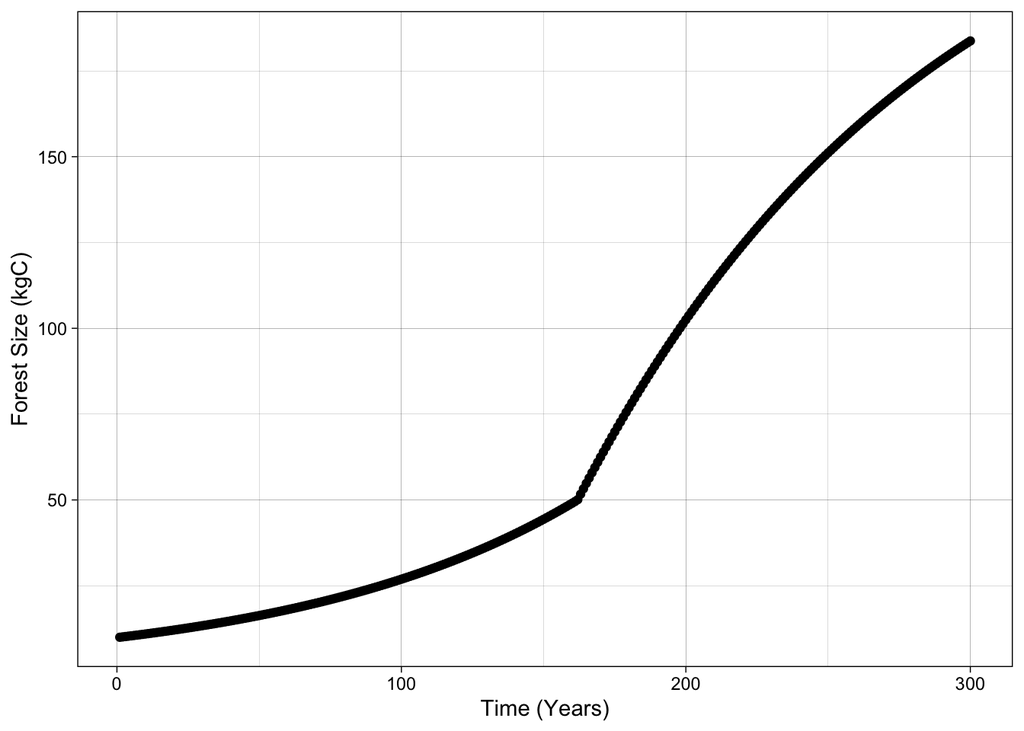

```r
ggplot(result, aes(time, `1`)) +
  geom_point() +
  theme_linedraw() +
  labs(x = "Time (Years)", y = "Forest Size (kgC)")
```

4. Run a Sobol global (vary all parameters at the same time) sensitivity analysis that explores how the estimated maximum forest size (e.g maximum of C 300 years, varies with these parameters
- pre canopy closure growth rate (r)
- post-canopy closure growth rate (g)
- canopy closure threshold and carrying capacity(K) Assume that parameters are all normally distributed with means as given above and standard deviation of 10% of mean value

```r
# Generate sobol parameters, st dev is 10% of mean value
num_samples <- 2000
carrying_capacity <- rnorm(mean = 250, sd = 250 * 0.01, n = num_samples)
pre_closure_rate <- rnorm(mean = 0.01, sd = 0.01 * 0.01, n = num_samples)
post_closure_rate <- rnorm(mean = 2, sd = 2 * 0.01, n = num_samples)
param_set1 <- cbind.data.frame(r = pre_closure_rate, K = carrying_capacity, g = post_closure_rate)

# Do for second set of samples
carrying_capacity <- rnorm(mean = 250, sd = 250 * 0.01, n = num_samples)
pre_closure_rate <- rnorm(mean = 0.01, sd = 0.01 * 0.01, n = num_samples)
post_closure_rate <- rnorm(mean = 2, sd = 2 * 0.01, n = num_samples)
param_set2 <- cbind.data.frame(r = pre_closure_rate, K = carrying_capacity, g = post_closure_rate)

# Fix negative vals
param_set1 <- param_set1 %>% map_df(pmax, 0.0)
param_set2 <- param_set2 %>% map_df(pmax, 0.0)
```

```r
# Run sobol model
sobol_result <- sobolSalt(model = NULL, X1 = param_set1, X2 = param_set2, nboot = 300)

# Add column names
colnames(sobol_result$X) <- c("r", "K", "g")

# Get results for 300 years (evaluating every year)
canopy_threshold <- 50
simulation_times <- seq(from = 1, to = 300)
params <- list(r = sobol_result$X[1, "r"],
               K = sobol_result$X[1, "K"],
               g = sobol_result$X[1, "g"])

# Run ode solver
ode_result <- ode(y = Cinitial,
                  times = simulation_times,
                  func = dforestgrowth,
                  parms = params,
                  thresh = canopy_threshold)

ode_result <- as.data.frame(ode_result)

# Rename the column names
colnames(ode_result) <- c("time", "C")
```

```r
# Create metrics function
calculate_metrics <- function(result, threshold) {
  max_growth <- max(result$C)

  index <- which(result$C > threshold)[1]
  index <- ifelse(is.na(index),
                  length(result$C),
                  index)

  threshold_year <- result$time[index]

  return(list(maxgrowth = max_growth, threshyear = threshold_year))
}

# Apply function to first param set
param_wrapper <- function(r, K, g, Cinitial, simtimes, odefunc, metricfunc, threshold) {
  params <- list(r = r, K = K, g = g)
  result <- ode(y = Cinitial,
                times = simtimes,
                func = odefunc,
                parms = params,
                thresh = threshold)
  colnames(result) <- c("time", "C")

  # Pull metrics
  metrics <- metricfunc(as.data.frame(result), thresh = 100)
  return(metrics)
}
```

```r
all_metrics <- as.data.frame(sobol_result$X) %>%
  pmap(param_wrapper,
       thresh = 50,
       Cinitial = Cinitial,
       simtimes = time,
       odefunc = dforestgrowth,
       metricfunc = calculate_metrics)

# Get results into a df
all_metrics_df <- all_metrics %>%
  map_dfr(`[`, c("maxgrowth", "threshyear"))
```

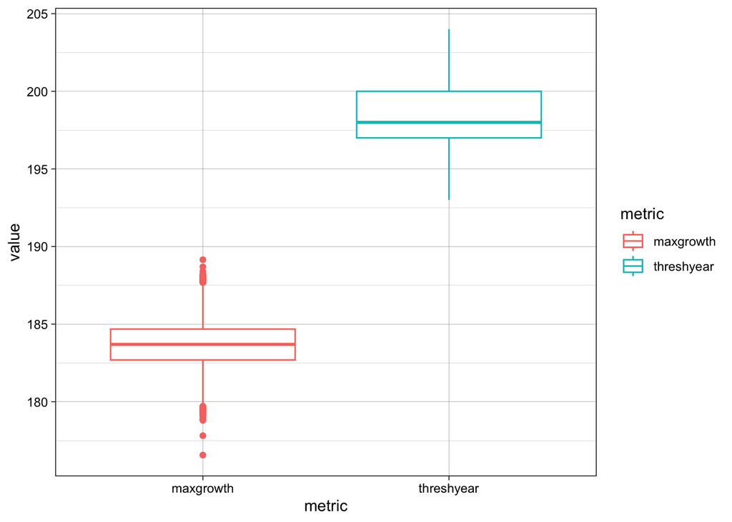

```r
# Build boxplots
tmp_data <- all_metrics_df %>%
  pivot_longer(cols = everything(),
               names_to = "metric",
               values_to = "value")

ggplot(tmp_data, aes(metric, value, color = metric)) +
  geom_boxplot() +
  theme_linedraw()
```

```r
# Get sobol indices
sobol_maxgrowth <- sensitivity::tell(sobol_result, all_metrics_df$maxgrowth)

# First-order indices (main effect without co-variance)
rownames(sobol_maxgrowth$S) <- c("r", "K", "g")
sobol_maxgrowth$S
```

```
##    original          bias std. error min. c.i. max. c.i.
## r 0.3426653  1.032824e-05 0.01921443 0.3050969 0.3809211
## K 0.3900764 -7.874735e-04 0.01996204 0.3519382 0.4313871
## g 0.2200684 -1.541845e-03 0.02204287 0.1791911 0.2659504
```

```r
# Total sensitivity index - note that this partitions the output variance
rownames(sobol_maxgrowth$T) <- c("r", "K", "g")
sobol_maxgrowth$T
```

```
##    original         bias  std. error min. c.i. max. c.i.
## r 0.3361944 0.0007185938 0.012613174 0.3119143 0.3601940
## K 0.4060724 0.0004249013 0.014952516 0.3754762 0.4322581
## g 0.2450983 0.0006279905 0.009885412 0.2234206 0.2629767
```

```r
# Get sobol indices for threshold year
sobol_threshyear <- sensitivity::tell(sobol_result, all_metrics_df$threshyear)

# First-order indices (main effect without co-variance)
rownames(sobol_threshyear$S) <- c("r", "K", "g")
sobol_threshyear$S
```

```
##       original          bias  std. error   min. c.i.  max. c.i.
## r  0.919627338 -1.555216e-05 0.003098753  0.91385706 0.92662359
## K -0.009960729  1.303248e-03 0.023058761 -0.05795647 0.03582431
## g  0.018241830 -7.899859e-05 0.023385493 -0.02822353 0.06537571
```

```r
# Total sensitivity index - note that this partitions the output variance - so values sum to 1
rownames(sobol_threshyear$T) <- c("r", "K", "g")
sobol_threshyear$T
```

```
##     original          bias  std. error  min. c.i.  max. c.i.
## r 0.95797809 -1.323287e-03 0.022057596 0.91658069 1.00313403
## K 0.03295377 -8.461802e-05 0.001813687 0.02953589 0.03632445
## g 0.07730797 -2.641289e-05 0.003433711 0.07133905 0.08500018
```

5. Graph the results of the sensitivity analysis as a box plot of maximum forest size and record the two Sobol indices (S and T).

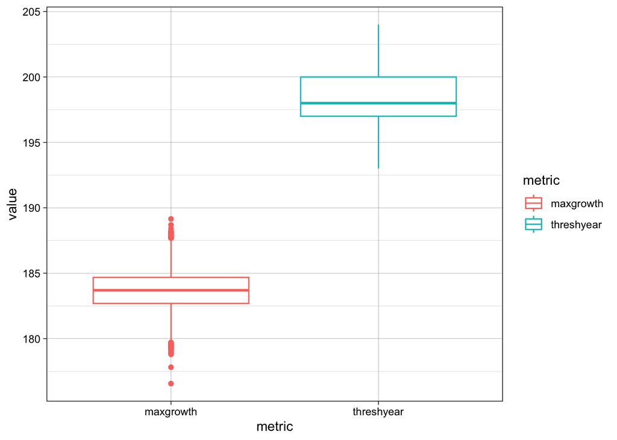

```r
# Boxplots
tmp_data <- all_metrics_df %>%
  pivot_longer(cols = everything(),
               names_to = "metric",
               values_to = "value")

ggplot(tmp_data, aes(metric, value, color = metric)) +
  geom_boxplot() +
  theme_linedraw()
```

```r
# Get sobol indices for max growth
sobol_maxgrowth <- sensitivity::tell(sobol_result, all_metrics_df$maxgrowth)

# First-order indices
rownames(sobol_maxgrowth$S) <- c("r", "K", "g")
sobol_maxgrowth$S
```

```
##    original          bias std. error min. c.i. max. c.i.
## r 0.3426653 -0.0011453193 0.01938156 0.3066561 0.3824773
## K 0.3900764 -0.0013922222 0.01960946 0.3519936 0.4318771
## g 0.2200684 -0.0003078549 0.02064222 0.1819905 0.2606670
```

```r
# Total sensitivity index
rownames(sobol_maxgrowth$T) <- c("r", "K", "g")
sobol_maxgrowth$T
```

```
##    original          bias  std. error min. c.i. max. c.i.
## r 0.3361944 -0.0003420145 0.011924237 0.3098745 0.3593111
## K 0.4060724  0.0001944910 0.013361364 0.3799165 0.4313075
## g 0.2450983  0.0001224932 0.009443871 0.2266104 0.2647173
```

```r
# Get sobol indices for threshold year
sobol_threshyear <- sensitivity::tell(sobol_result, all_metrics_df$threshyear)

# First-order indices
rownames(sobol_threshyear$S) <- c("r", "K", "g")
sobol_threshyear$S
```

```
##       original         bias  std. error   min. c.i.  max. c.i.
## r  0.919627338 -0.000158581 0.003417531  0.91313173 0.92632822
## K -0.009960729 -0.001679789 0.022641042 -0.05547658 0.03264325
## g  0.018241830 -0.001574829 0.022533447 -0.02565003 0.06247456
```

```r
# Total sensitivity index, values sum to 1
rownames(sobol_threshyear$T) <- c("r", "K", "g")
sobol_threshyear$T
```

```
##     original          bias  std. error  min. c.i.  max. c.i.
## r 0.95797809  0.0018634845 0.022609775 0.91518911 1.00047379
## K 0.03295377 -0.0001244256 0.001911873 0.02907071 0.03685388
## g 0.07730797  0.0002566163 0.003350031 0.07093965 0.08375482
```

6. In 2-3 sentences, discuss what the results of your simulation might mean. (For example think about how what parameters climate change might influence).

Looking at the results of the sensitivity analysis, maximum forest growth is most heavily influenced by the carrying capacity and pre-closure growth rate. The threshold year is primarily determined by the pre-closure growth rate (r). Climate change could impact these parameters since changes in temperature and precipitation patterns are likely to affect forest carrying capacity and growth rates Understanding and analyzing the sensitivity of forest growth to these parameters can help us predict, manage and understand the potential response of forests to a range of future climate scenarios.